# Poster Energy vs Angle Plots

```python
import os
from pathlib import Path

testfolder = str(Path().resolve().parent / 'TEMP' /  'Agu2023Ovaitt')

if not os.path.exists(testfolder):
    os.makedirs(testfolder)

print ("Your simulation will be stored in %s" % testfolder)
```

```
Your simulation will be stored in C:\Users\sayala\Documents\GitHub\InSPIRE\Studies\TEMP\Agu2023Ovaitt
```

```python
import bifacial_radiance as br
import numpy as np
import pandas as pd
import bifacialvf
import pvlib
import matplotlib.pyplot as plt
import pickle
```

```python
# This information helps with debugging and getting support :)
import sys, platform
print("Working on a ", platform.system(), platform.release())
print("Python version ", sys.version)
print("Pandas version ", pd.__version__)
print("bifacial_radiance version ", br.__version__)
print("bifacialvf version ", bifacialvf.__version__)
print("pvlib version ", pvlib.__version__)
```

```
Working on a  Windows 10
Python version  3.11.4 | packaged by Anaconda, Inc. | (main, Jul  5 2023, 13:38:37) [MSC v.1916 64 bit (AMD64)]
Pandas version  2.1.0
bifacial_radiance version  0.4.2+236.g6801d3d
bifacialvf version  0.1.7-dev1+71.g202ed86
pvlib version  0.9.5
```

```python
plt.rcParams.update({'font.size': 15})
plt.rcParams['figure.figsize'] = (10, 8)
```

```python
downloadData = False
if downloadData == True:
    NREL_API_KEY = None  # <-- please set your NREL API key here

    # note you must use "quotes" around your key, for example:
    # NREL_API_KEY = 'DEMO_KEY'  # single or double both work fine

    # during the live tutorial, we've stored a dedicated key on our server
    if NREL_API_KEY is None:
        try:
            NREL_API_KEY = os.environ['NREL_API_KEY']  # get dedicated key for tutorial from servier
        except KeyError:
            NREL_API_KEY = 'DEMO_KEY'  # OK for this demo, but better to get your own key

    df_tmy, metadata = pvlib.iotools.get_psm3(
        latitude=37.3022, longitude=-120.4830,
        api_key=NREL_API_KEY,
        email='silvana.ovaitt@nrel.gov',  # <-- any email works here fine
        names='tmy',
        map_variables=True)

    df_tmy['Year'] = 2023
    df_tmy.index = pd.to_datetime(df_tmy[['Year', 'Month', 'Day', 'Hour', 'Minute']])

    # saving
    df_tmy.to_pickle(os.path.join(testfolder, 'df_tmy.pkl'))
    metadatafile = os.path.join(testfolder, 'metadata.pkl')
    with open(metadatafile, 'wb') as handle:
        pickle.dump(metadata, handle, protocol=pickle.HIGHEST_PROTOCOL)

else:
    df_tmy = pd.read_pickle(os.path.join(testfolder, 'df_tmy.pkl'))
    metadatafile = os.path.join(testfolder, 'metadata.pkl')
    with open(metadatafile, 'rb') as handle:
        metadata = pickle.load(handle)
```

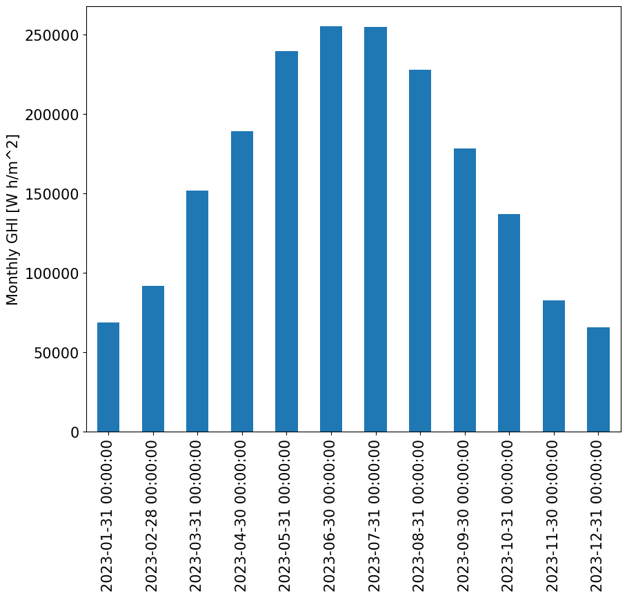

```python
monthly = df_tmy['ghi'].resample('M').sum()
monthly.plot.bar()
plt.ylabel('Monthly GHI [W h/m^2]');

'''
fig_eDemands, ax0 = plt.subplots()#1,1,figsize=(8,6), sharey=True,
                                    #  gridspec_kw={'wspace': 2, 'width_ratios': [1]})
ax0.bar(monthly.index, monthly.values)
ax0.set_xticklabels(labels=['Feb','Apr', 'Jun', 'Aug', 'Oct', 'Dec'], rotation=0,fontsize=14)
'''
```

```python
df_tmy = df_tmy.tz_localize('Etc/GMT+8')
```

```python
location = pvlib.location.Location(latitude=metadata['latitude'],
                                   longitude=metadata['longitude'])

solar_position = location.get_solarposition(times = df_tmy.index)

tracker_data = pvlib.tracking.singleaxis(solar_position['apparent_zenith'],
                                         solar_position['azimuth'],
                                         axis_azimuth=180,
                                         backtrack=False,
                                         max_angle=60)

tilt = tracker_data['surface_tilt'].fillna(0)
azimuth = tracker_data['surface_azimuth'].fillna(0)

df_tmy['zenith'] = solar_position['zenith']
df_tmy['solar_azimuth'] = solar_position['azimuth']

df_tmy['true_tilt'] = tilt
df_tmy['true_azimuth'] = azimuth

tracker_data = pvlib.tracking.singleaxis(solar_position['apparent_zenith'],
                                         solar_position['azimuth'],
                                         axis_azimuth=180,
                                         backtrack=True,
                                         max_angle=60)

tilt = tracker_data['surface_tilt'].fillna(0)
azimuth = tracker_data['surface_azimuth'].fillna(0)

df_tmy['backtracking_tilt'] = tilt
df_tmy['backtracking_azimuth'] = azimuth


df_poa_tracker = pvlib.irradiance.get_total_irradiance(surface_tilt=tilt,
                                                       surface_azimuth=azimuth,
                                                       dni=df_tmy['dni'],
                                                       ghi=df_tmy['ghi'],
                                                       dhi=df_tmy['dhi'],
                                                       solar_zenith=solar_position['apparent_zenith'],
                                                       solar_azimuth=solar_position['azimuth'])

tracker_poa = df_poa_tracker['poa_global']

parameters = pvlib.temperature.TEMPERATURE_MODEL_PARAMETERS['sapm']['open_rack_glass_polymer']
cell_temperature = pvlib.temperature.sapm_cell(tracker_poa,
                                               df_tmy['temp_air'],
                                               df_tmy['wind_speed'],
                                               **parameters)

gamma_pdc = -0.004  # divide by 100 to go from %/°C to 1/°C
nameplate = 1e3
array_power = pvlib.pvsystem.pvwatts_dc(tracker_poa, cell_temperature, nameplate, gamma_pdc)

df_tmy['backtracking_Power'] = array_power

df_tmy['backtracking_POA'] = tracker_poa
```

```python
start_date = pd.to_datetime('2023-06-21 00:30:00-08:00')
end_date = pd.to_datetime('2023-06-21 23:30:00-08:00')
foo = df_tmy[(df_tmy.index>start_date) & (df_tmy.index<end_date)]
foo = foo[foo.ghi > 10]
foo
```

|  | Year | Month | Day | Hour | Minute | temp_air | Dew Point | dhi | dni | ghi | ... | wind_direction | wind_speed | zenith | solar_azimuth | true_tilt | true_azimuth | backtracking_tilt | backtracking_azimuth | backtracking_Power | backtracking_POA |
| --- | --- | --- | --- | --- | --- | --- | --- | --- | --- | --- | --- | --- | --- | --- | --- | --- | --- | --- | --- | --- | --- |
| 2023-06-21 05:30:00-08:00 | 2023 | 6 | 21 | 5 | 30 | 14.0 | 8.0 | 41.0 | 348.0 | 88.0 | ... | 261.0 | 1.8 | 82.315524 | 66.314411 | 60.000000 | 90.000000 | 22.669250 | 90.000000 | 209.862041 | 205.524104 |
| 2023-06-21 06:30:00-08:00 | 2023 | 6 | 21 | 6 | 30 | 17.0 | 8.0 | 73.0 | 619.0 | 274.0 | ... | 256.0 | 1.8 | 71.081820 | 74.484807 | 60.000000 | 90.000000 | 60.000000 | 90.000000 | 633.447011 | 660.958813 |
| 2023-06-21 07:30:00-08:00 | 2023 | 6 | 21 | 7 | 30 | 20.0 | 8.0 | 92.0 | 756.0 | 477.0 | ... | 273.0 | 1.7 | 59.399615 | 82.503489 | 59.155250 | 90.000000 | 59.155250 | 90.000000 | 785.864275 | 849.860148 |
| 2023-06-21 08:30:00-08:00 | 2023 | 6 | 21 | 8 | 30 | 23.0 | 8.0 | 256.0 | 424.0 | 542.0 | ... | 282.0 | 1.8 | 47.498153 | 91.130338 | 47.474258 | 90.000001 | 47.474258 | 90.000001 | 617.128314 | 660.429446 |
| 2023-06-21 09:30:00-08:00 | 2023 | 6 | 21 | 9 | 30 | 26.0 | 8.0 | 377.0 | 277.0 | 602.0 | ... | 287.0 | 2.2 | 35.652290 | 101.764040 | 35.066243 | 90.000000 | 35.066243 | 90.000000 | 585.708672 | 631.482130 |
| 2023-06-21 10:30:00-08:00 | 2023 | 6 | 21 | 10 | 30 | 28.0 | 7.0 | 111.0 | 922.0 | 951.0 | ... | 291.0 | 2.5 | 24.414215 | 117.909820 | 21.849791 | 90.000000 | 21.849791 | 90.000000 | 897.268664 | 1020.142519 |
| 2023-06-21 11:30:00-08:00 | 2023 | 6 | 21 | 11 | 30 | 30.0 | 7.0 | 114.0 | 935.0 | 1015.0 | ... | 296.0 | 3.0 | 15.640646 | 149.951306 | 7.977851 | 90.000004 | 7.977851 | 90.000004 | 895.592848 | 1023.874753 |
| 2023-06-21 12:30:00-08:00 | 2023 | 6 | 21 | 12 | 30 | 31.0 | 6.0 | 115.0 | 936.0 | 1020.0 | ... | 302.0 | 3.3 | 14.945744 | 203.891430 | 6.168348 | 269.999995 | 6.168348 | 269.999995 | 894.501782 | 1025.025984 |
| 2023-06-21 13:30:00-08:00 | 2023 | 6 | 21 | 13 | 30 | 31.0 | 6.0 | 119.0 | 916.0 | 962.0 | ... | 307.0 | 3.6 | 23.079785 | 239.218634 | 20.100770 | 270.000000 | 20.100770 | 270.000000 | 892.757155 | 1020.088707 |
| 2023-06-21 14:30:00-08:00 | 2023 | 6 | 21 | 14 | 30 | 31.0 | 5.0 | 113.0 | 894.0 | 853.0 | ... | 310.0 | 3.8 | 34.158410 | 256.591612 | 33.415231 | 269.999999 | 33.415231 | 269.999999 | 884.445896 | 1007.679841 |
| 2023-06-21 15:30:00-08:00 | 2023 | 6 | 21 | 15 | 30 | 31.0 | 5.0 | 209.0 | 571.0 | 606.0 | ... | 312.0 | 3.9 | 45.968265 | 267.659736 | 45.926985 | 270.000000 | 45.926985 | 270.000000 | 694.892335 | 771.001792 |
| 2023-06-21 16:30:00-08:00 | 2023 | 6 | 21 | 16 | 30 | 30.0 | 4.0 | 89.0 | 790.0 | 509.0 | ... | 311.0 | 4.0 | 57.880415 | 276.443403 | 57.689933 | 270.000000 | 57.689933 | 270.000000 | 791.353606 | 884.328414 |
| 2023-06-21 17:30:00-08:00 | 2023 | 6 | 21 | 17 | 30 | 28.0 | 4.0 | 71.0 | 670.0 | 305.0 | ... | 309.0 | 3.6 | 69.603582 | 284.490395 | 60.000000 | 270.000000 | 60.000000 | 270.000000 | 656.496017 | 715.714289 |
| 2023-06-21 18:30:00-08:00 | 2023 | 6 | 21 | 18 | 30 | 25.0 | 5.0 | 43.0 | 435.0 | 112.0 | ... | 303.0 | 2.9 | 80.908451 | 292.607934 | 60.000000 | 270.000000 | 27.227192 | 270.000000 | 276.883922 | 285.310613 |

14 rows × 22 columns

```python
import matplotlib.dates as mdates
myFmt = mdates.DateFormatter('%m-%d')
plt.rcParams.update({'font.size': 20})
plt.rcParams['figure.figsize'] = (10, 8)
```

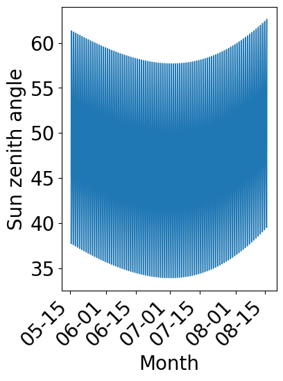

```python
fig, ax0 = plt.subplots(1,1,figsize=(4,6))#, sharey=True,
                                    #  gridspec_kw={'wspace': 2, 'width_ratios': [1]})

start_date = pd.to_datetime('2023-05-15 00:30:00-08:00')
end_date = pd.to_datetime('2023-08-15 23:30:00-08:00')
foo = df_tmy[(df_tmy.index>start_date) & (df_tmy.index<end_date)]
#foo = foo[foo.ghi > 10]
ax0.plot(foo.between_time('14:30','16:30')['zenith'])
#ax0.set_xticks(['a','b', 'c'])
fig.autofmt_xdate(rotation=45)
ax0.xaxis.set_major_formatter(myFmt)
ax0.set_ylabel('Sun zenith angle')
ax0.set_xlabel('Month')
##ax0.set_xticklabels(rotation=90)
#ax0.set_xticklabels(labels=['May 15','Jun', 'Jul', 'Aug', 'Sept', 'Oct'], rotation=0,fontsize=14)
```

```python
start_date = pd.to_datetime('2023-05-15 00:30:00-08:00')
end_date = pd.to_datetime('2023-08-15 23:30:00-08:00')
foo = df_tmy[(df_tmy.index>start_date) & (df_tmy.index<end_date)]
foo = foo.between_time('14:30','16:30')
```

```python
energy_mod = pd.DataFrame()
poa_mod = pd.DataFrame()

tilts=[0.0,2.0,4.0,6.0,8.0,10.0,15.0,20.0]

for ii in range(0,len(tilts)):
    foo['new_tilt'] = foo['backtracking_tilt'].copy().values-tilts[ii]
    foo.loc[foo['new_tilt']<0, 'new_tilt'] = 0.0
    foo.loc[foo['new_tilt']>60, 'new_tilt'] = 60.0

    df_poa_tracker = pvlib.irradiance.get_total_irradiance(surface_tilt=foo['new_tilt'],
                                                           surface_azimuth=foo['backtracking_azimuth'],
                                                           dni=foo['dni'],
                                                           ghi=foo['ghi'],
                                                           dhi=foo['dhi'],
                                                           solar_zenith=foo['zenith'],
                                                           solar_azimuth=foo['solar_azimuth'])

    tracker_poa = df_poa_tracker['poa_global']

    parameters = pvlib.temperature.TEMPERATURE_MODEL_PARAMETERS['sapm']['open_rack_glass_polymer']
    cell_temperature = pvlib.temperature.sapm_cell(tracker_poa,
                                                   foo['temp_air'],
                                                   foo['wind_speed'],
                                                   **parameters)

    gamma_pdc = -0.004  # divide by 100 to go from %/°C to 1/°C
    nameplate = 1e3
    array_power = pvlib.pvsystem.pvwatts_dc(tracker_poa, cell_temperature, nameplate, gamma_pdc)
    energy_mod[str(tilts[ii])] = 100-array_power*100/foo['backtracking_Power']
    poa_mod[str(tilts[ii])] = foo['backtracking_POA']-tracker_poa
```

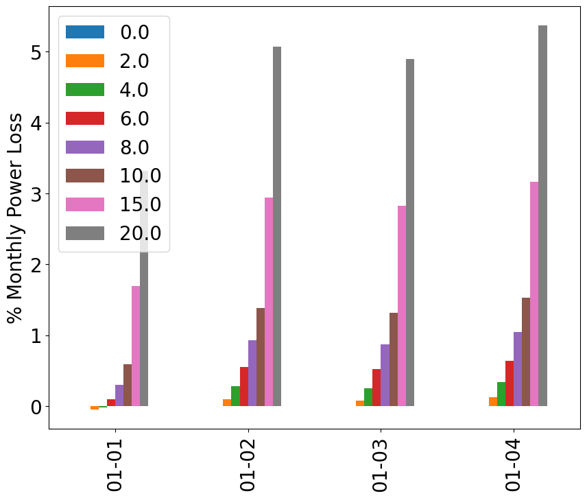

```python
monthly = energy_mod.resample('M').mean()
monthly.plot.bar()
plt.ylabel('% Monthly Power Loss');
ax = plt.gca()
ax.xaxis.set_major_formatter(mdates.DateFormatter('%m-%d'))
```

```python
foo.keys()
```

```
Index(['Year', 'Month', 'Day', 'Hour', 'Minute', 'temp_air', 'Dew Point',
       'dhi', 'dni', 'ghi', 'albedo', 'pressure', 'wind_direction',
       'wind_speed', 'zenith', 'solar_azimuth', 'true_tilt', 'true_azimuth',
       'backtracking_tilt', 'backtracking_azimuth', 'backtracking_Power',
       'backtracking_POA'],
      dtype='object')
```

## PVLIB PVFACTORS

```python
start_date = pd.to_datetime('2023-05-15 00:30:00-08:00')
end_date = pd.to_datetime('2023-08-15 23:30:00-08:00')
foo = df_tmy[(df_tmy.index>start_date) & (df_tmy.index<end_date)]
foo = foo.between_time('14:30','16:30')
foo
```

|  | Year | Month | Day | Hour | Minute | temp_air | Dew Point | dhi | dni | ghi | ... | wind_direction | wind_speed | zenith | solar_azimuth | true_tilt | true_azimuth | backtracking_tilt | backtracking_azimuth | backtracking_Power | backtracking_POA |
| --- | --- | --- | --- | --- | --- | --- | --- | --- | --- | --- | --- | --- | --- | --- | --- | --- | --- | --- | --- | --- | --- |
| 2023-05-15 14:30:00-08:00 | 2023 | 5 | 15 | 14 | 30 | 27.4 | 3.7 | 195.0 | 698.0 | 748.0 | ... | 319.0 | 5.1 | 37.761387 | 251.595821 | 36.302376 | 270.000000 | 36.302376 | 270.000000 | 801.385454 | 879.061739 |
| 2023-05-15 15:30:00-08:00 | 2023 | 5 | 15 | 15 | 30 | 27.4 | 3.6 | 103.0 | 827.0 | 643.0 | ... | 320.0 | 5.0 | 49.400707 | 263.445118 | 49.195319 | 270.000000 | 49.195319 | 270.000000 | 848.741011 | 936.895194 |
| 2023-05-15 16:30:00-08:00 | 2023 | 5 | 15 | 16 | 30 | 26.1 | 3.7 | 91.0 | 736.0 | 446.0 | ... | 320.0 | 4.8 | 61.310504 | 272.843407 | 60.000000 | 270.000000 | 60.000000 | 270.000000 | 764.464527 | 831.253166 |
| 2023-05-16 14:30:00-08:00 | 2023 | 5 | 16 | 14 | 30 | 30.0 | 6.3 | 127.0 | 847.0 | 799.0 | ... | 288.0 | 2.7 | 37.618602 | 251.893042 | 36.208438 | 270.000000 | 36.208438 | 270.000000 | 848.519964 | 965.653035 |
| 2023-05-16 15:30:00-08:00 | 2023 | 5 | 16 | 15 | 30 | 30.1 | 5.3 | 109.0 | 814.0 | 641.0 | ... | 286.0 | 2.9 | 49.270002 | 263.696022 | 49.078572 | 270.000000 | 49.078572 | 270.000000 | 820.721885 | 929.018883 |
| ... | ... | ... | ... | ... | ... | ... | ... | ... | ... | ... | ... | ... | ... | ... | ... | ... | ... | ... | ... | ... | ... |
| 2023-08-14 15:30:00-08:00 | 2023 | 8 | 14 | 15 | 30 | 35.0 | 4.0 | 101.0 | 814.0 | 617.0 | ... | 279.0 | 3.8 | 50.528923 | 256.839793 | 49.758328 | 270.000000 | 49.758328 | 270.000000 | 794.200880 | 911.761990 |
| 2023-08-14 16:30:00-08:00 | 2023 | 8 | 14 | 16 | 30 | 33.0 | 5.0 | 85.0 | 732.0 | 424.0 | ... | 283.0 | 4.2 | 62.343399 | 267.060922 | 60.000000 | 270.000000 | 60.000000 | 270.000000 | 730.614209 | 820.916008 |
| 2023-08-15 14:30:00-08:00 | 2023 | 8 | 15 | 14 | 30 | 35.0 | 4.0 | 95.0 | 902.0 | 789.0 | ... | 290.0 | 4.0 | 39.533399 | 243.365745 | 36.404118 | 270.000000 | 36.404118 | 270.000000 | 840.228721 | 969.497005 |
| 2023-08-15 15:30:00-08:00 | 2023 | 8 | 15 | 15 | 30 | 34.0 | 4.0 | 86.0 | 858.0 | 628.0 | ... | 297.0 | 4.2 | 50.754812 | 256.554466 | 49.951925 | 269.999999 | 49.951925 | 269.999999 | 824.275942 | 942.640722 |
| 2023-08-15 16:30:00-08:00 | 2023 | 8 | 15 | 16 | 30 | 33.0 | 4.0 | 77.0 | 769.0 | 429.0 | ... | 301.0 | 4.3 | 62.561519 | 266.803173 | 60.000000 | 270.000000 | 60.000000 | 270.000000 | 756.127088 | 851.893806 |

279 rows × 22 columns

```python
# example array geometry
pvrow_height = 1.5
pvrow_width = 2
pitch = 5.7
gcr = pvrow_width / pitch
axis_azimuth = 180
albedo = 0.2
parameters = pvlib.temperature.TEMPERATURE_MODEL_PARAMETERS['sapm']['open_rack_glass_polymer']
bifaciality = 0.7
gamma_pdc = -0.004  # divide by 100 to go from %/°C to 1/°C
nameplate = 1e3
```

```python
# Bifi BASELINE
irrad = pvlib.bifacial.pvfactors_timeseries(
    solar_azimuth=foo['solar_azimuth'],
    solar_zenith=foo['zenith'],
    surface_azimuth=foo['backtracking_azimuth'],  # south-facing array
    surface_tilt=foo['backtracking_tilt'],
    axis_azimuth=0, # 90 degrees off from surface_azimuth.  270 is ok too
    timestamps=foo.index,
    dni=foo['dni'],
    dhi=foo['dhi'],
    gcr=gcr,
    pvrow_height=pvrow_height,
    pvrow_width=pvrow_width,
    albedo=albedo,
    n_pvrows=3,
    index_observed_pvrow=1
)

irrad = pd.concat(irrad, axis=1)


effective_irrad_bifi = irrad['total_abs_front'] + (irrad['total_abs_back']
                                                   * bifaciality)
effective_irrad_mono = irrad['total_abs_front']

# bifi
cell_temperature = pvlib.temperature.sapm_cell(effective_irrad_bifi,
                                               foo['temp_air'],
                                               foo['wind_speed'],
                                               **parameters)
array_power_bifi = pvlib.pvsystem.pvwatts_dc(effective_irrad_bifi, cell_temperature, nameplate, gamma_pdc)

foo['backtracking_Power_bifi'] = array_power_bifi

# bifi
cell_temperature = pvlib.temperature.sapm_cell(effective_irrad_mono,
                                               foo['temp_air'],
                                               foo['wind_speed'],
                                               **parameters)
array_power_mono = pvlib.pvsystem.pvwatts_dc(effective_irrad_mono, cell_temperature, nameplate, gamma_pdc)

foo['backtracking_Power_mono'] = array_power_mono
```

```python
energy_bifi = pd.DataFrame()
energy_mono = pd.DataFrame()

tilts=[0.0,2.0,4.0,6.0,8.0,10.0,15.0,20.0, 40.0]

for ii in range(0,len(tilts)):
    foo['new_tilt'] = foo['backtracking_tilt'].copy().values-tilts[ii]
    foo.loc[foo['new_tilt']<0, 'new_tilt'] = 0.0
    foo.loc[foo['new_tilt']>60, 'new_tilt'] = 60.0

    irrad = pvlib.bifacial.pvfactors.pvfactors_timeseries(
        solar_azimuth=foo['solar_azimuth'],
        solar_zenith=foo['zenith'],
        surface_azimuth=foo['backtracking_azimuth'],  # south-facing array
        surface_tilt=foo['new_tilt'],
        axis_azimuth=0, # 90 degrees off from surface_azimuth.  270 is ok too
        timestamps=foo.index,
        dni=foo['dni'],
        dhi=foo['dhi'],
        gcr=gcr,
        pvrow_height=pvrow_height,
        pvrow_width=pvrow_width,
        albedo=albedo,
        n_pvrows=3,
        index_observed_pvrow=1
    )

    irrad = pd.concat(irrad, axis=1)


    effective_irrad_bifi = irrad['total_abs_front'] + (irrad['total_abs_back']
                                                       * bifaciality)
    effective_irrad_mono = irrad['total_abs_front']

    # bifi
    cell_temperature = pvlib.temperature.sapm_cell(effective_irrad_bifi,
                                                   foo['temp_air'],
                                                   foo['wind_speed'],
                                                   **parameters)
    array_power_bifi = pvlib.pvsystem.pvwatts_dc(effective_irrad_bifi, cell_temperature, nameplate, gamma_pdc)

    # mono
    cell_temperature = pvlib.temperature.sapm_cell(effective_irrad_mono,
                                                   foo['temp_air'],
                                                   foo['wind_speed'],
                                                   **parameters)
    array_power_mono = pvlib.pvsystem.pvwatts_dc(effective_irrad_mono, cell_temperature, nameplate, gamma_pdc)

    energy_bifi[str(tilts[ii])] = 100-array_power_bifi*100/(foo['backtracking_Power_bifi'])
    energy_mono[str(tilts[ii])] = 100-array_power_mono*100/(foo['backtracking_Power_mono'])
```

[output not shown]

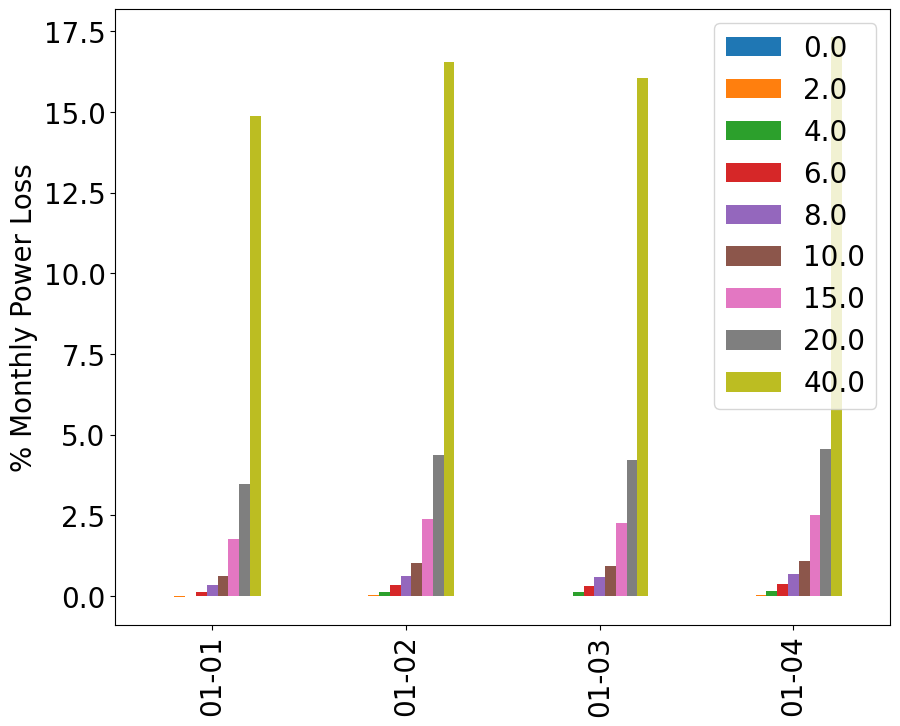

```python
monthly_bifi = energy_bifi.resample('M').mean()
monthly_bifi.plot.bar()
plt.ylabel('% Monthly Power Loss');
ax = plt.gca()
ax.xaxis.set_major_formatter(mdates.DateFormatter('%m-%d'))
```

```python
monthly_mono = energy_mono.resample('M').mean()
```

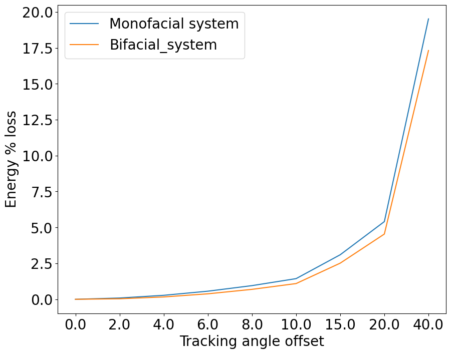

```python
plt.plot(monthly_mono.iloc[3],label='Monofacial system')
plt.plot(monthly_bifi.iloc[3], label='Bifacial_system')
plt.legend()
plt.xlabel('Tracking angle offset')
plt.ylabel('Energy % loss')
```

## MERCED Raytrace

```python
simulationname = 'tutorial_1'

# Scene Parameters:
azimuth_ang=180 # Facing south
tilt =35 # tilt.

# MakeModule Parameters
moduletype='test-module'
numpanels = 1  # AgriPV site has 3 modules along the y direction
module_x = 2 # m
module_y = 1 # m. slope we will measure
# if x > y, landscape. if x < y, portrait
xgap = 0.0#
ygap = 0.0 # Leaving 10 centimeters between modules on y direction
zgap = 0.0
sensorsy = 10  # this will give 6 sensors per module, 1 per cell

# SceneDict Parameters
pitch = 5.7 # m
albedo = 0.2  #'grass'     # ground albedo
hub_height = 1.5 # m
nMods = 10 # six modules per row.
nRows = 5  # 3 row
```

```python
demo = br.RadianceObj(simulationname,path = testfolder)
demo.setGround(albedo)
epwfile = demo.getEPW(lat, lon) # NJ lat/lon 40.0583° N, 74.4057
```

```
path = C:\Users\sayala\Documents\GitHub\InSPIRE\Studies\TEMP\Agu2023Ovaitt
Making path: images
Making path: objects
Making path: results
Making path: skies
Making path: EPWs
Making path: materials
Loading albedo, 1 value(s), 0.200 avg
1 nonzero albedo values.
```

[output not shown]

```python
# Making module, either as a black Unit or with cell-level detail.
# Suggest to use cell-level only for visualizations, and or for studying customly made agriPV modules where the cell
# gaps might be really, really wide. Most commercial panels can be approximated by the single-black surface.
detailedModule = False

if detailedModule:
    cellModule = {'numcellsx': numcellsx, 'numcellsy':numcellsy,
                             'xcell': xcell, 'ycell': ycell, 'xcellgap': xcellgap, 'ycellgap': ycellgap}
    module=demo.makeModule(name=moduletype,numpanels=numpanels,
                           xgap=xgap, ygap=ygap, cellModule=cellModule, tubeParams=tubeParams)
else:
    module=demo.makeModule(name=moduletype,x=module_x,y=module_y,numpanels=numpanels,
                           xgap=xgap, ygap=ygap, tubeParams=tubeParams)
```

```python
#Determine Hour to model
#Valid options: mm_dd, mm_dd_HH, mm_dd_HHMM, YYYY-mm-dd_HHMM
metdata = demo.readWeatherFile(epwfile, coerce_year=2021, starttime='2021-06-21_12', endtime='2021-06-21_13')
```

```python
demo.metdata.__dict__
```

```python
metdata.__dict__
```

We are going to model just one single timeindex at a time.

```python
timeindex = metdata.datetime.index(pd.to_datetime('2021-06-21 12:0:0 -5'))  # Make this timezone aware, use -5 for EST.
timeindex
```

```python
demo.genCumSky()
```

```python
demo.gendaylit(timeindex=timeindex)
```

```python
sceneDict = {'tilt':tilt,'pitch': 15,'hub_height':hub_height,'azimuth':azimuth_ang, 'nMods': nMods, 'nRows': nRows}
scene = demo.makeScene(module=moduletype, sceneDict=sceneDict)
```

```python
octfile = demo.makeOct(demo.getfilelist())
```

If desired, you can view the Oct file at this point:

*rvu -vf views\front.vp -e .01 tutorial_1.oct*

```python
## Comment the ! line below to run rvu from the Jupyter notebook instead of your terminal.
## Simulation will stop until you close the rvu window

!rvu -vf views\front.vp -e .01 tutorial_1.oct
```

And adjust the view parameters, you should see this image.

[figure not shown]

## 4. Adding different Albedo Sections

For practicing adding custom scene elements, we will add a patch in the ground that has a different reflectivity (albedo) than the average set for the field. By using this `genbox` and giving it the right size/position, we can create trees, buildings, or secondary small-area surfaces to add with sampling at specific heights but that do not shade the scene.

```python
name='Center_Patch'
patchpositionx=-14
patchpositiony=2
text='! genbox white_EPDM CenterPatch 28 12 0.001 | xform -t {} {} 0'.format(patchpositionx, patchpositiony)
customObject = demo.makeCustomObject(name,text)
demo.appendtoScene(scene.radfiles, customObject)
octfile = demo.makeOct(demo.getfilelist())
```

```python
#!rvu -vf views\front.vp -e .01 tutorial_1.oct
#!rvu -vf views\front.vp -e .01 -pe 0.4 -vp 12 -10 3.5 -vd -0.0995 0.9950 0.0 tutorial_1.oct
```

Viewing with rvu:

[figure not shown]

## 2. Analyse the Ground Irradiance

Now let's do some analysis along the ground, starting from the edge of the modules. We wil select to start in the center of the array.

We are also increasign the number of points sampled accross the collector width, with the variable **sensorsy** passed to **moduleanalysis**. We are also increasing the step between sampling points, to be able to sample in between the rows.

```python
analysis = br.AnalysisObj(octfile, demo.name)
frontscan, backscan = analysis.moduleAnalysis(scene, sensorsy=sensorsy, modWanted=4)
```

```python
frontscan
```

```python
groundscan = frontscan
```

```python
groundscan['zstart'] = 0.05  # setting it 5 cm from the ground.
groundscan['zinc'] = 0   # no tilt necessary.
groundscan['yinc'] = pitch/(sensorsy-1)   # increasing spacing so it covers all distance between rows
groundscan['orient'] = '0 0 -1'
groundscan
```

```python
analysis.analysis(octfile, simulationname+"_groundscan", groundscan, backscan)  # compare the back vs front irradiance
```

This is the result for only one 'chord' accross the ground. Let's now do a X-Y scan of the ground.

## 3. Analyse and MAP the Ground Irradiance

We will use the same technique to find the irradiance on the ground used above, but will move it along the X-axis to map from the start of one module to the next.

We will sample around the module that is placed at the center of the field.

[figure not shown]

```python
import seaborn as sns
```

```python
sensorsx = 3
startgroundsample=-module.scenex
spacingbetweensamples = module.scenex/(sensorsx-1)

for i in range (0, sensorsx): # Will map 20 points
    frontscan, backscan = analysis.moduleAnalysis(scene, sensorsy=sensorsy)
    groundscan = frontscan
    groundscan['zstart'] = 0.05  # setting it 5 cm from the ground.
    groundscan['zinc'] = 0   # no tilt necessary.
    groundscan['yinc'] = pitch/(sensorsy-1)   # increasing spacing so it covers all distance between rows
    groundscan['xstart'] = startgroundsample + i*spacingbetweensamples   # increasing spacing so it covers all distance between rows
    analysis.analysis(octfile, simulationname+"_groundscan_"+str(i), groundscan, backscan)  # compare the back vs front irradiance
```

Read all the files generated into one dataframe

```python
filestarter = "irr_tutorial_1_groundscan_"

filelist = sorted(os.listdir(os.path.join(testfolder, 'results')))
prefixed = [filename for filename in filelist if filename.startswith(filestarter)]
arrayWm2Front = []
arrayWm2Back = []
arrayMatFront = []
arrayMatBack = []
filenamed = []
faillist = []

print('{} files in the directory'.format(filelist.__len__()))
print('{} groundscan files in the directory'.format(prefixed.__len__()))
i = 0  # counter to track # files loaded.

for i in range (0, len(prefixed)):
    ind = prefixed[i].split('_')

    try:
        resultsDF = br.load.read1Result(os.path.join(testfolder, 'results', prefixed[i]))
        arrayWm2Front.append(list(resultsDF['Wm2Front']))
        arrayWm2Back.append(list(resultsDF['Wm2Back']))
        arrayMatFront.append(list(resultsDF['mattype']))
        arrayMatBack.append(list(resultsDF['rearMat']))
        filenamed.append(prefixed[i])
    except:
        print(" FAILED ", i, prefixed[i])
        faillist.append(prefixed[i])

resultsdf = pd.DataFrame(list(zip(arrayWm2Front, arrayWm2Back,
                                  arrayMatFront, arrayMatBack)),
                         columns = ['br_Wm2Front', 'br_Wm2Back',
                                    'br_MatFront', 'br_MatBack'])
resultsdf['filename'] = filenamed
```

Creating a new dataframe where each element in the front irradiance list is a column. Also transpose and reverse so it looks like a top-down view of the ground.

```python
df3 = pd.DataFrame(resultsdf['br_Wm2Front'].to_list())
reversed_df = df3.T.iloc[::-1]
```

```python
sns.set(rc={'figure.figsize':(11.7,8.27)})
```

```python
# Plot
ax = sns.heatmap(reversed_df)
ax.set_yticks([])
ax.set_xticks([])
ax.set_ylabel('')
ax.set_xlabel('')
print('')
```